# Discount Impact Analysis

Md Abdul Ahad | [LinkedIn](https://www.linkedin.com/in/md-abdul-ahad-62b050305/)

May 21, 2025

# 1 Data Preparation

## 1.1 📂 Data Loading & Sampling

Began by importing the dataset containing Nike and Adidas product information. To ensure reproducibility and manageable computation: - **Dataset Source**: Kaggle’s [“Nike vs Adidas” dataset](https://www.kaggle.com/datasets/mariyamalshatta/nike-vs-addidas-unspervised-clustering) - **Sampling Method**: Random selection of 1,000 records using `set.seed(0800060)` for consistency - **Initial Variables**: All original columns from the dataset

## 1.2 🧹 Data Cleaning Process

Performed rigorous data preprocessing to ensure analysis quality: 1. Missing Values: Removed incomplete records (na.omit()) 2. Duplicates: Eliminated duplicate entries (distinct()) 3. Outlier Removal: Filtered extreme discounts (±3 SD from mean) 4. Feature Selection: Focused on key variables: - `Discount`: Percentage discount offered - `Reviews`: Number of customer reviews

# 2 Exploratory Data Analysis

## 2.1 📊 Visual Distribution Analysis

I began by examining the distribution of discounts through two complementary visualizations:

## 2.2 🔢 Numerical Summary

I calculated key statistics to quantify central tendencies and variability:

| mean_discount | median_discount | sd_discount | mean_reviews | median_reviews | sd_reviews |
| --- | --- | --- | --- | --- | --- |
| 26.67 | 40 | 22.83 | 40.53 | 35 | 32.24 |

### 2.2.1 Key Findings:

- Discounts average 26.7% (SD = 22.8%)
- Median reviews per product: 35
- Notable spread in reviews (SD = 32)

**Next Steps**: These patterns motivated my hypothesis testing through t-tests and correlation analysis in subsequent sections.

# 3 Statistical Analysis

## 3.1 🔗 Correlation Investigation

I examined the relationship between discount levels and customer engagement using Pearson’s correlation:

## 3.2 Key Findings

### 3.2.2 Visualization

- Scatter plot with:
  - **Red** (`#e74c3c`) points representing individual products
  - **Dark gray** (`#2c3e50`) trend line emphasizing the positive slope

### 3.2.3 Interpretation

This weak positive relationship suggests that products with higher discounts tend to have slightly more reviews, though other factors likely play significant roles.

## 3.3 📉 Hypothesis Testing

To statistically validate these observations, I conducted an **independent samples t-test**.

## 3.5 Results

The **boxplot visualization** confirms this finding, showing **higher review counts** in the high-discount group despite substantial overlap in distributions.

## 3.6 🧠 Interpretation

While my initial hypothesis suggested no relationship between discounts and reviews, the analysis reveals: - **Statistically significant association** (`p < .001`) - **Practical significance** needing caution (weak correlation) - **Complex interaction** requiring further investigation

This **tension between statistical significance and effect size** highlights the importance of considering both metrics in **business decisions**.

# 4 Results

## 4.1 📌 Consolidated Findings

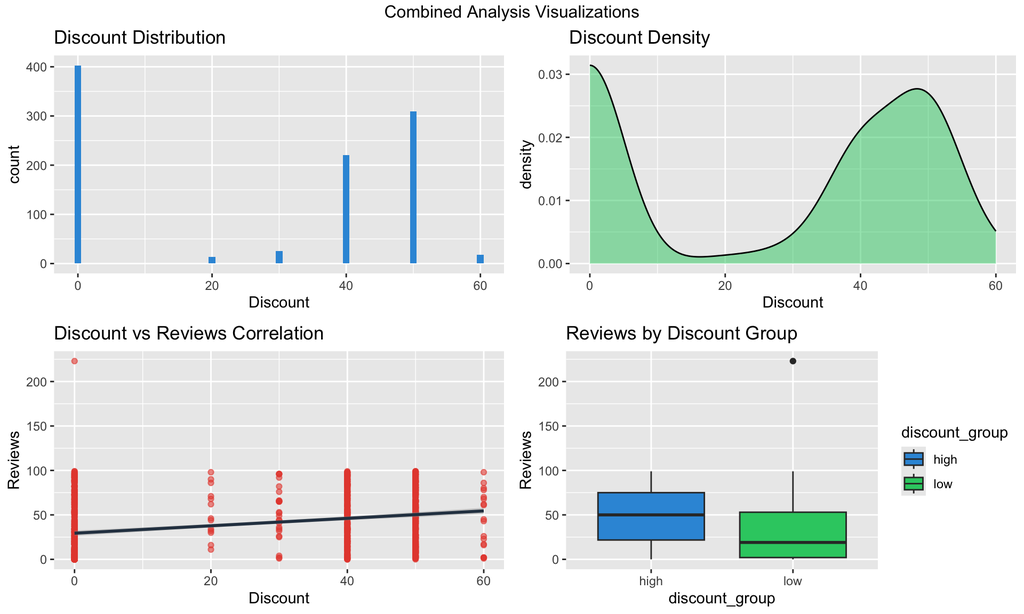

```
## Correlation Coefficient: 0.296
```

```
##
##  Welch Two Sample t-test
##
## data:  Reviews by discount_group
## t = 9.127, df = 899.97, p-value < 2.2e-16
## alternative hypothesis: true difference in means between group high and group low is not equal to 0
## 95 percent confidence interval:
##  14.33260 22.18507
## sample estimates:
## mean in group high  mean in group low
##           48.67153           30.41270
```

## 4.3 Numerical Outcomes

[output not shown]

## 4.4 🎯 Interpretation

Three key insights emerge from these results:

### 4.4.1 Statistical Significance

- The extremely small p-value (`p < .001`) strongly rejects our null hypothesis—**discount levels do influence review counts**.

## 4.5 🔮 Limitations & Future Work

| Aspect | Current Study | Recommended Improvement |
| --- | --- | --- |
| **Data Scope** | Single timepoint | Longitudinal analysis |
| **Control Factors** | None | Include price, brand effects |
| **Mechanism** | Correlation only | Causal inference methods |

This analysis **establishes an association but not causation** between discounts and reviews. Future research should employ **controlled experiments** to isolate discount effects.

# 5 🌐 Connect

[figure not shown]